# Juvenile Snowshoe hare physical data: An exploratory report

Erin de Leon Sanchez

11/7/2021

### A. Introduction:

This report covers an exploratory overview of juvenile Snowshoe hare physical data from the Bonanza Creek Long Term Ecological Research (LTER) site from 1999 - 2012. The Snowshoe hare, *Lepus americanus*, is a keystone prey species in northern boreal forests and experience population fluctuations of 8-11-years and these data were collected to estimate Snowshoe hare population densities and growth over time. Here, annual juvenile hare trap counts are reported to see population size fluctuation over time. To explore the physical data, we report a comparison of juvenile hare weights by sex and site (grid) as well as a juvenile weight comparison by sex. We conclude the report with an exploration of the relationship between juvenile Snowshoe hare weight and hind foot length.

### B. Data and analyses:

Juvenile snowshoe hare physical data were collected and made available by Knut Kielland, F. Stuart Chapin, and Roger W. Ruess at the Bonanza Creek Experimental Forest LTER, approximately 20 km southwest of Fairbanks, Alaska in the Tanana Valley State Forest. These data are from capture-recapture studies of snowshoe hares at 5 locales, although only three sites (grids) are included in this report, in the Tanana valley from 1999 to 2012. Following exploratory data visualization, weights for male and female juvenile hares are compared through Effect size (Cohen’s *d*) an unpaired two-sample t-test. The relationship between weight and hind foot length is explored by linear regression. All analyses are in R version 3.6.2 using RStudio version RStudio 2021.09.0+351 for macOS.

#### i. Annual juvenile Snowshoe hare trap counts

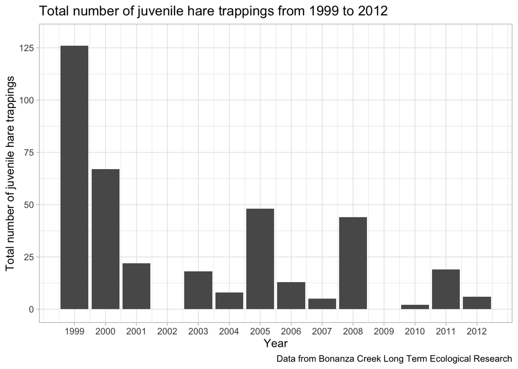

#### ii. A comparison of juvenile Snowshoe hare weights by sex and site (grid)

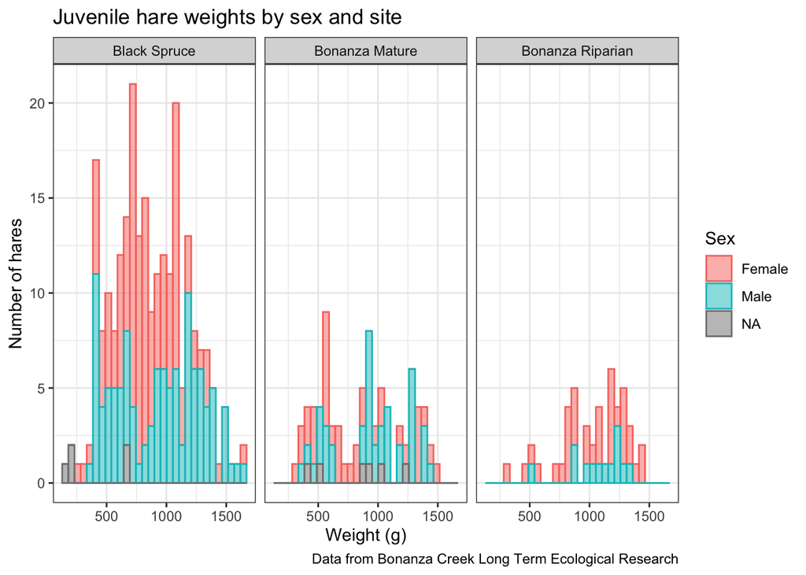

**Figure 2:** Juvenile Snowshoe hare weight distribution by sex and site.

Main takeaways:

- Weight distribution of both juvenile male and female hares is not normally distributed, regardless of site.
- There are greater numbers of juvenile female hares distributed across the range of weights across the three sites, as compared to juvenile male hares.

#### iii. Juvenile Snowshoe hare weight comparison between sexes

Table 1: Summary statistics for juvenile snowshoe hares

| Sex | Mean weight (g) | Standard Deviation (g) | Sample size (n) |
| --- | --- | --- | --- |
| Female | 855.39 | 292.25 | 200 |
| Male | 945.86 | 333.22 | 163 |
| NA | 614.55 | 357.59 | 15 |

#### iv. Relationship between juvenile Snowshoe hare weight & hind foot length.

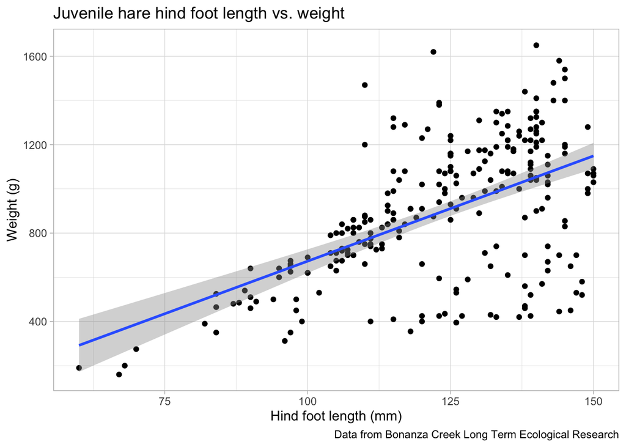

### Citations:

Data citation: Kielland, K., F.S. Chapin, R.W. Ruess, and Bonanza Creek LTER. 2017. Snowshoe hare physical data in Bonanza Creek Experimental Forest: 1999-Present ver 22. Environmental Data Initiative. https://doi.org/10.6073/pasta/03dce4856d79b91557d8e6ce2cbcdc14